# Rainfall and temperature data

Lyndon Estes

2019-02-11

## Overview

This vignette describes additional datasets needed for the variability in planting dates, yield prediction, and rainfall variability projects.

## Data

Two relevant datasets come bundled with this project. Several other datasets need to be downloaded from the links provided and then read in (we are not bundling them with the package because of their size)

```r
library(geospaarproj)
library(geospaar)
library(rgdal)

# SMS survey
f <- system.file("extdata/sms-data.csv", package = "geospaarproj")
sms <- read.csv(f, stringsAsFactors = FALSE)

# Rainfall collected at sensor pods
f <- system.file("extdata/pod-rainfall.csv", package = "geospaarproj")
podrf <- read.csv(f)
```

The `sms` data you will be familiar with from the yield and planting date vignette, so we covered the farmer rainfall report variable there.

### Pod rainfall

New here is the `podrf` dataset, that contains the daily rainfall totals from 7 environmental sensor pods that were deployed in the Southern Province of Zambia in 2015/2016. Here’s a look at the spatial distribution of those pods, and what the data values look like:

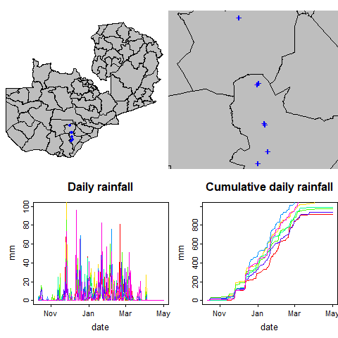

```r
coordinates(podrf) <- ~lon + lat
podrf$date <- as.Date(podrf$date, "%Y-%m-%d")
data("districts")

par(mfrow = c(2, 2), mar = c(0, 0, 1, 0))
plot(districts, col = "grey")
points(podrf, col = "blue", pch = 20)
plot(podrf, pch = "")
plot(districts, col = "grey", add = TRUE)
points(podrf, col = "blue", pch = "+")

# rainfall values
pods <- unique(podrf$podid)
cols <- rainbow(length(pods))
par(mar = c(3, 3, 3, 0), mgp = c(1.5, 0.25, 0), tcl = -0.2)
plot(rain ~ date, podrf[podrf$podid == pods[1], ], type = "l", ylab = "mm",
     col = cols[1], ylim = c(0, 100), main = "Daily rainfall", cex.axis = 0.8)
for(i in 2:length(pods)) {
  lines(rain ~ date, podrf[podrf$podid == pods[i], ], col = cols[i])
}
plot(cumsum(rain) ~ date, podrf[podrf$podid == pods[1], ], type = "l",
     col = cols[1], ylim = c(0, 1000), main = "Cumulative daily rainfall",
     cex.axis = 0.8, ylab = "mm")
for(i in 2:length(pods)) {
  lines(cumsum(rain) ~ date, podrf[podrf$podid == pods[i], ], col = cols[i])
}
```

These rainfall data represent point observations that can be compared with the gridded values provided by the CHIRPs datasets (which we have a sample of in the `geospaar` package).

### CHIRPS

We have pre-processed the CHIRPs data to provide daily observations for each ~5X5 km pixel in Zambia for the years 2008-2017. The grids themselves can be downloaded from these links:

- [2008](https://www.dropbox.com/s/h7phahgdbmoftxq/zam_chirps2008.tif?dl=0)
- [2009](https://www.dropbox.com/s/0igf7kvmwtfwvty/zam_chirps2009.tif?dl=0)
- [2010](https://www.dropbox.com/s/t5hjtohtoifjmk0/zam_chirps2010.tif?dl=0)
- [2011](https://www.dropbox.com/s/h0nvsc1so6dubas/zam_chirps2011.tif?dl=0)
- [2012](https://www.dropbox.com/s/190qoq9peuqpr3d/zam_chirps2012.tif?dl=0)
- [2013](https://www.dropbox.com/s/g3fzasqzpw4vpu0/zam_chirps2013.tif?dl=0)
- [2014](https://www.dropbox.com/s/z17cvypaj2ylydk/zam_chirps2014.tif?dl=0)
- [2015](https://www.dropbox.com/s/uhzbh91i0espugn/zam_chirps2015.tif?dl=0)
- [2016](https://www.dropbox.com/s/gfwmntoy7f6wkj1/zam_chirps2016.tif?dl=0)
- [2017](https://www.dropbox.com/s/01w1xhf6x7n6mye/zam_chirps2017.tif?dl=0)

These datasets can be downloaded to a location of your choosing and then read in. The 2008-2017 times series should be useful for identifying variation in rainfall start dates in each year (sometime in the Oct-Dec timeframe), which is part of the planting date variability/rainfall variability analysis.

For the spatial variability of rainfall project, the 2015 (October-December layers) and 2016 (January-April layers) CHIRPS data will be important.

Here is an example of how you can work with the data in both cases, using code that assumes the data are already downloaded to a particular location. You will need the `lubridate` package for this, as we are going to use that to create date vectors, which will be helpful for subsetting rainfall layers out of the various CHIRPS bricks.

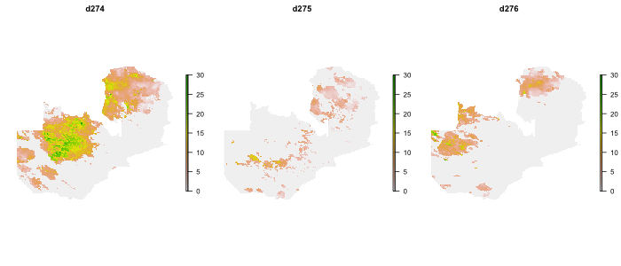

```r
library(lubridate)
library(raster)

# path to CHIRPS, assuming they are all downloaded
p_chrp <- "~/Dropbox/data/climate/rainfall/zambia/chirps/"

# contruct vector of file names
fnms <- paste0(p_chrp, paste0("/zam_chirps", 2008:2017, ".tif"))


# read in 2015 and 2016 CHIRPs data into a stack
chrp1516 <- stack(lapply(2015:2016, function(x) {  # x <- 2015
  b <- brick(fnms[grep(x, fnms)])
  b
}))
names(chrp1516) <- paste0("d", 1:nlayers(chrp1516))

# construct date look-up table that gives you date of each layer
dts <- seq(ymd("2015-01-01"), ymd("2016-12-31"), by = "day")
dts <- data.frame("yr" = year(dts), "date" = dts)

# index of October 1 - April 30 dates
ind <- which(dts$date >= "2015-10-01" & dts$date <= "2016-04-30")
chrp1516_gs <- chrp1516[[ind]]

png("vignettes/chrpfig.png", height = 300, width = 700)
plot_noaxes(chrp1516_gs[[1:3]], nr = 1, nc = 3, zlim = c(0, 30))
dev.off()
```

This plot shows the first three dates in that subset, which are days 274, 275, and 276 in the two year time series, or 2015-10-01, 2015-10-02, 2015-10-03.

Let’s say you wanted to collect the last three months of each year in order to undertake an analysis of variation in the start date of the rainfall season. You could it this way.

```r
chrp_start <- lapply(2008:2016, function(x) {  # x <- 2008
  print(x)
  dts <- seq(ymd(paste0(x, "-01-01")), ymd(paste0(x, "-12-31")), by = "day")
  dts <- data.frame("yr" = year(dts), "date" = dts)
  ind <- which(dts$date >= paste0(x, "-10-01") &
    dts$date <= paste0(x, "-12-31"))
  b <- brick(fnms[grep(x, fnms)])
  b <- b[[ind]]
  names(b) <- paste0("d", ind)
  b
})
```

In this case we only read in the CHIRPS data for 2008-2016, because 2017’s data only goes until September. The code above selects from each year’s CHIRPS brick the last three months of data.

So that gives the beginning steps for how you might read in the data. You will then want to do your analyses on it. How you do that is something for us to discuss.

### Temperature data

To accompany the precipitation data, we have improved temperature data from the Princeton Global Forcing dataset [@sheffield_development_2006], which we pre-processed into GeoTiffs for the years 2015 and 2016, as documented in the PGF temperature prep vignette. Pre-pre-processing of the data was done by [Professor Justin Sheffield](https://www.southampton.ac.uk/geography/about/staff/js1c15.page) of University of Southampton Department of Geopgraphy and Environment, to make the temperature data consistent with another precipitation dataset used by our broader research group.

The data in question are not bundled with this package, but can be downloaded from the links here:

[2015 TMin](https://www.dropbox.com/s/hhbpxoh5q90ye36/tmin_2015.tif?dl=0) [2015 TMax](https://www.dropbox.com/s/oq07ao297yj276c/tmax_2015.tif?dl=0) [2015 TMean](https://www.dropbox.com/s/6madmuc16diao6i/tmean_2015.tif?dl=0) [2016 TMin](https://www.dropbox.com/s/mro9h1itdxsxz0c/tmin_2016.tif?dl=0) [2016 TMax](https://www.dropbox.com/s/8ef7ie47soctl71/tmax_2016.tif?dl=0) [2016 TMean](https://www.dropbox.com/s/hh2lt5tx4xptj48/tmean_2016.tif?dl=0)

The datasets provide daily minimum (TMin), maximum (TMax), and mean (TMean) temperatures for each of the two years, in separate bricks.

The following shows how you can load the data and process monthly means from the daily means, using the same `dts` vector, with some additions, to subset the data.

We’ll also introduce a new concept: parallel computing to speed-up the calculation of the mean on multiple months

[figure not shown]

```r
library(doMC)
library(foreach)

# set up
dts <- seq(ymd("2015-01-01"), ymd("2016-12-31"), by = "day")
dts <- data.frame("yr" = year(dts), "mo" = month(dts), "date" = dts)
unimos <- unique(dts[, c("yr", "mo")])
unimos$moind <- 1:nrow(unimos)
dts <- merge(dts, unimos, by = c("yr", "mo"))
dts <- dts[order(dts$date), ]
# dts[342:500, ]

# path to PGF temp
p_temp <- "~/Dropbox/data/climate/temp/zambia/"

# contruct vector of file names
fnms <- paste0(p_temp, paste0("tmean_", 2015:2016, ".tif"))

# Read in TMean for 2015 and 2016
tmu1516 <- stack(lapply(fnms, function(x) {  # x <- 2015
  b <- brick(x)
}))
names(tmu1516) <- paste0("d", 1:nlayers(tmu1516))

# prepare indices for October 1 - April 30 dates
dyind <- which(dts$date >= "2015-10-01" & dts$date <= "2016-04-30")
dts_ss <- dts[dyind, ]  # subset data.frame of dates

# subset temp stack
tmu1516_gs <- tmu1516[[dyind]]

# calculate monthly means, the normal serial way - slow
tmu_mo_ser <- stack(lapply(unique(dts_ss$moind), function(x) {  # x <- 10
  moind <- which(dts_ss$moind == x)
  calc(tmu1516_gs[[moind]], mean)
}))
names(tmu_mo_ser) <- paste0("mo", c(10:12, 1:4))

# calculate monthly means in parallel, using doMC and foreach
# foreach behaves very much like lapply
registerDoMC(7)  # dedicate 7 of my 8 cores, one per month to calculate
tmu_mo_par <- foreach(x = unique(dts_ss$moind), .combine = stack) %dopar% {
  moind <- which(dts_ss$moind == x)
  calc(tmu1516_gs[[moind]], mean)
}
names(tmu_mo_par) <- paste0("mo", c(10:12, 1:4))

# run this to make sure parallel and serial versions are identical
# (in case you don't trust that parallel version ordered months correctly)
for(i in 1:nlayers(tmu_mo_par)) {
  print(identical(tmu_mo_par[[i]], tmu_mo_ser[[i]]))
}  # you will see that TRUE for each layer

tmu_mo_par <- tmu_mo_par - 273.15  # data are in Kelvin, so convert to celsius

png("vignettes/tmu.png", height = 300, width = 700)
plot_noaxes(tmu_mo_par, nr = 2, nc = 3, zlim = c(15, 35))
dev.off()
```